# Math 421 - Midterm

```r
df$pay_method <- case_when(
  df$pay_ub92 == 1 ~ 'Medicare',
  df$pay_ub92 == 2 ~ 'Medicare Managed Care',
  df$pay_ub92 == 3 ~ 'Medicaid Fee for Service',
  df$pay_ub92 == 4 ~ 'RIte Care',
  df$pay_ub92 == 5 ~ 'Out-of-state Medicaid Managed Care',
  df$pay_ub92 == 6 ~ 'Blue Cross',
  df$pay_ub92 == 7 ~ 'Blue Chip',
  df$pay_ub92 == 8 ~ 'United Health Care',
  df$pay_ub92 == 9 ~ 'Commercial insurance (Other than listed)',
  df$pay_ub92 == 10 ~ 'Champus',
  df$pay_ub92 == 11 ~ 'Workers Compensation',
  df$pay_ub92 == 12 ~ 'Other',
  df$pay_ub92 == 13 ~ 'Self Pay',
  df$pay_ub92 == 14 ~ 'Free care',
  df$pay_ub92 == 15 ~ 'NHP Comm')
  #TRUE ~ 'Missing/Error'
```

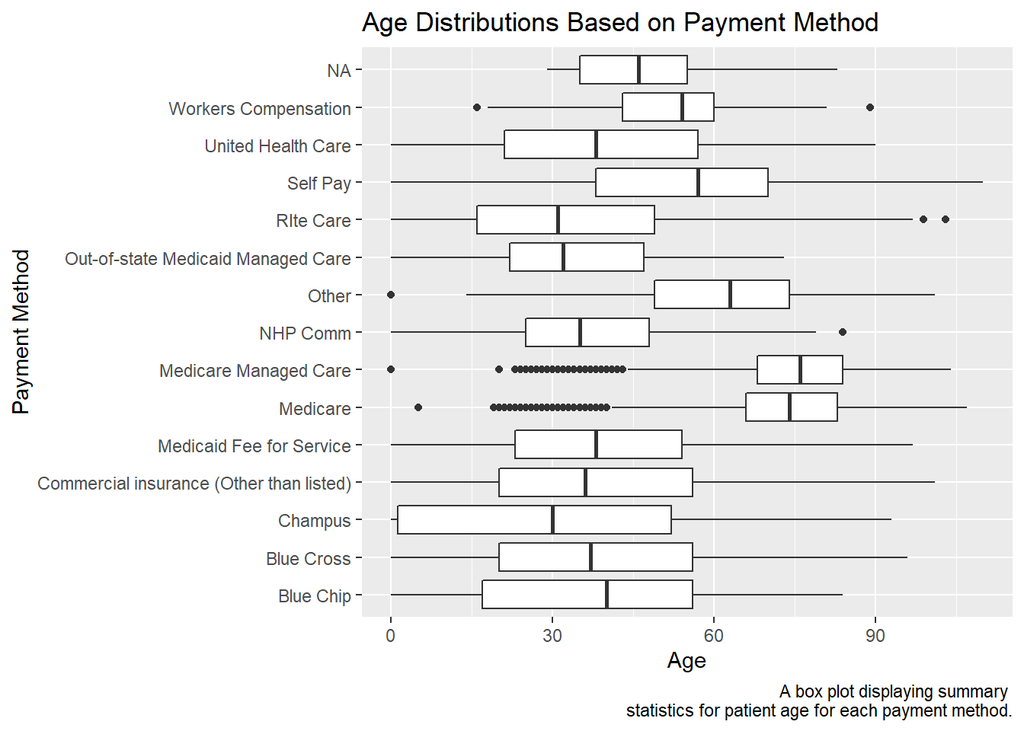

```r
#plot 9
df %>%
  ggplot()+
  geom_boxplot(mapping = aes(x = age, y = pay_method))+
  labs(x='Age',
       y='Payment Method',
       title='Age Distributions Based on Payment Method',
       caption='A box plot displaying summary
       statistics for patient age for each payment method.')
```

```r
df$ageRange <- case_when(
  df$age < 20 ~ '0-20',
  df$age %in% (21:40) ~ '21-40',
  df$age %in% (41:60) ~ '41-60',
  df$age %in% (61:80) ~ '61-80',
  df$age %in% (81:100) ~ '81-100',)
```

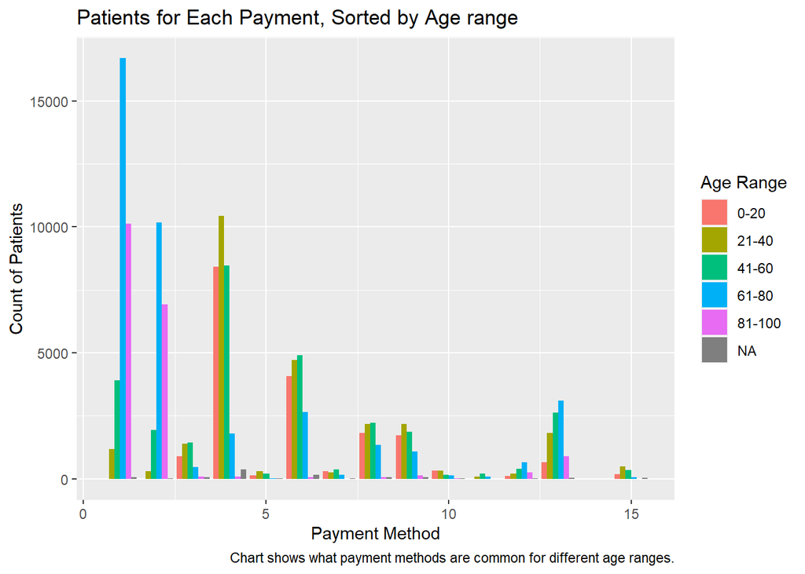

```r
#plot 10
df %>% filter(pay_ub92 < 20) %>% ggplot() + geom_bar(mapping=aes(x=pay_ub92, fill=ageRange), position = 'dodge') +
  labs(x='Payment Method',
       y='Count of Patients',
       fill = 'Age Range',
       title = 'Patients for Each Payment, Sorted by Age range',
       caption = 'Chart shows what payment methods are common for different age ranges.')
```

2. Make an animation plot.

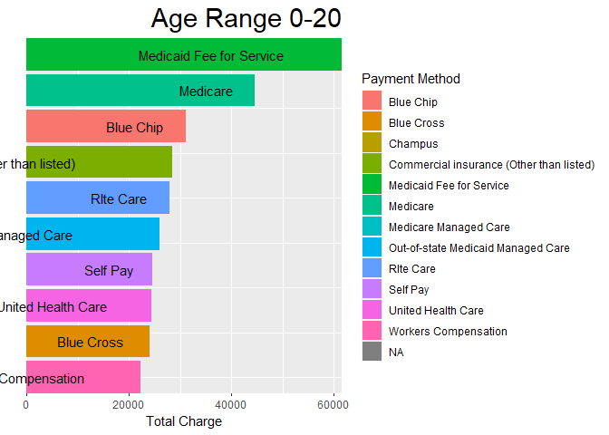

```r
library(gganimate)
library(gifski)
library(ggplot2)
library(tidyverse)
library(knitr)
library(lubridate)

d1 <- df %>% group_by(ageRange, pay_method) %>% summarise(avg_tot = mean(tot))
d2 <- d1 %>% group_by(ageRange) %>% mutate(rank=rank(-avg_tot))
d3 <- d2 %>% filter(rank <= 10)
a1 <- d3 %>% ggplot(aes(x=rank, y=avg_tot, group=pay_method, fill=pay_method, label=pay_method)) + geom_col()+
    geom_text(aes(y = avg_tot, label = pay_method), hjust = 1.4)+
    coord_flip(clip = "off", expand = FALSE) +scale_x_reverse()+
    labs(title = 'Age Range {closest_state}', x='', y='Total Charge', fill='Payment Method')+
    theme(plot.title = element_text(hjust = 1, size = 22),
          axis.ticks.y = element_blank(),
          axis.text.y  = element_blank()) +
    transition_states(ageRange)+
    ease_aes("cubic-in-out")
animate(a1, nframes = 200)
```

3. Write a paragraph to summarize the section and give your comments on the results.

I was able to create many significant plots for visualization of trends and better understanding the data. In particular, plot 6 was able to give a lot of information, giving us a noticeable sine-like pattern and a difference between male and female patients. Otherwise, I was able to find lots of information about different payment types, breaking them up by sex, age, and age range. Options like medicare were popular for older patients, and workers compensation was more popular for make patients. I am happy with the results that i was able to get because many of the plots show something interesting and significant about the data.

## III. Predictive Models

Continue with the data from part I. Make sure you do not have any missing values in the data. Use the follows as the target and input variables:

*Target Variable*: Create the target variable taking value of

- `low` if the total charge of a patient (`tot`) is smaller than the median of the total charge, and
- `high` otherwise.

```r
df$target <- case_when(df$tot < median(df$tot) ~ 'low',TRUE ~ 'high')
```

*Input Variables*:

- “age”,“sex”,“raceethn”,“provider”,“moa”,“mod”,“admtype”,“campus”, ‘los’

```r
df3 <- df %>% select("age", "sex", "raceethn", "provider", "moa", "mod", "admtype", "campus", "los", "target")
```

1. Use `filter` function to filter out rows where `raceethn==''` or `admtype==''`. Make sure all the categorical variables are factor, numeric variables are numeric. Set Training : Testing Split = 10 : 90

```r
library(tidyverse)
library(caret)

df3 <- df3 %>%
  filter(raceethn!='',admtype!='') %>%
  mutate(target=as.factor(target),
    sex=as.factor(sex),
    raceethn=as.factor(raceethn),
    provider=as.factor(provider),
    admtype=as.factor(admtype),
    campus=as.factor(campus))

set.seed(2020)
parts <- createDataPartition(df3$target, p = .1, list = FALSE)

traindf <- df3[ parts,]
testdf <- df3[-parts,]
```

2. Train a decision tree using `rpart`. Plot the decision tree. Plot the variable importance ranked by the tree.

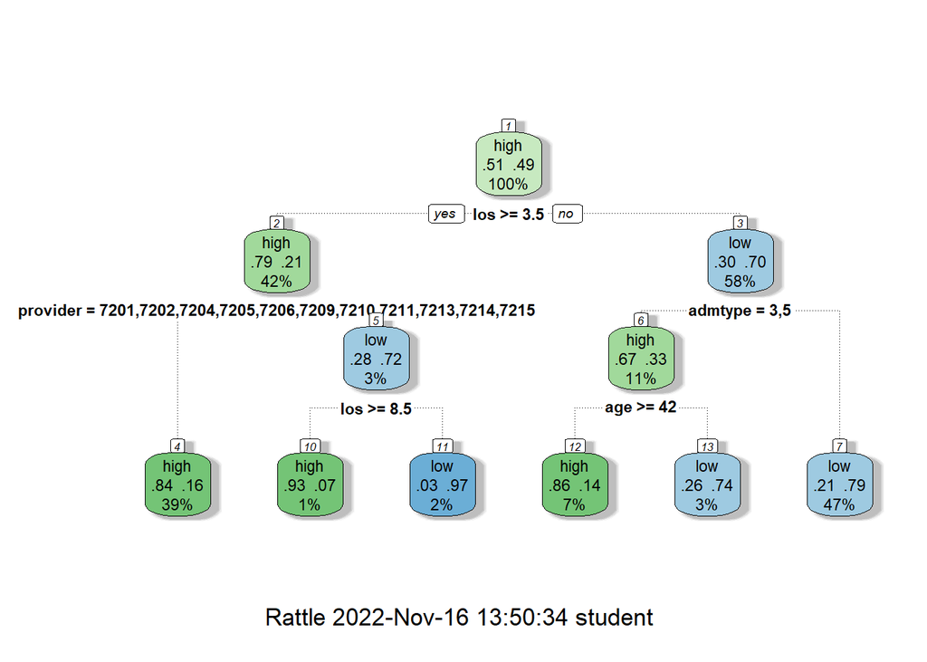

```r
library(rpart)
treedf <- rpart(target ~ ., data = traindf, control = rpart.control(maxdepth = 3))
library(rattle)
fancyRpartPlot(treedf)
```

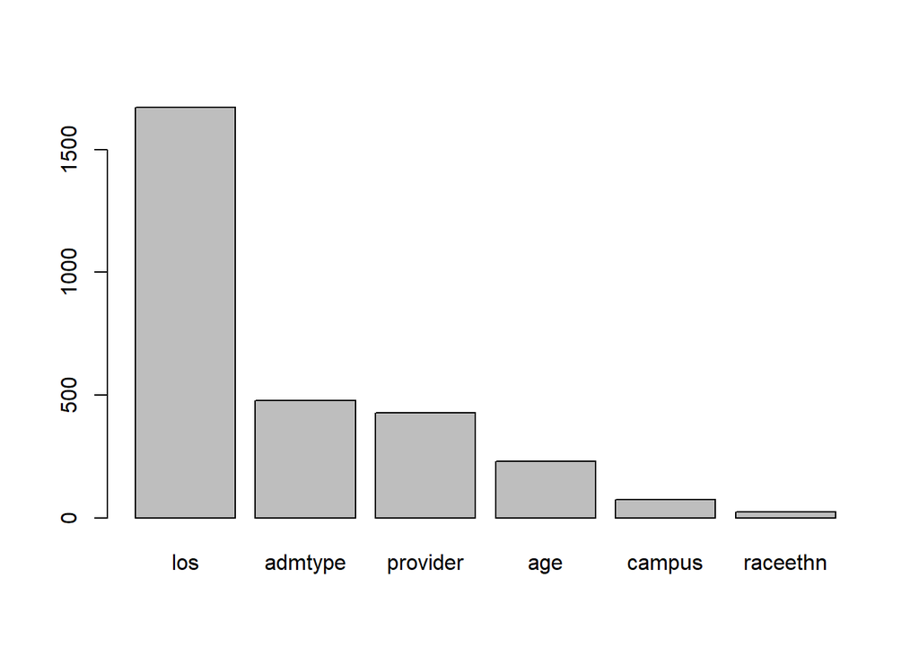

```r
barplot(treedf$variable.importance)
```

3. Using caret for this question. Set `Training Control` to be: Use Cross-Validation of 5 folds across all models. Train & tune at least 2 different models (i.e. two different values for `method=` in the train function of caret). Plot the hyper-parameter tuning plots for each model.

```r
library(tidyverse)
library(caret)
library(mlbench)
```

```r
trControl = trainControl(method = "cv",number = 5)
tuneGrid = expand.grid(mtry = 2:4,splitrule = c('gini', 'extratrees'),min.node.size = c(1:10))
model2 <- train(target ~ ., data=traindf,method = "treebag",trControl = trControl, maxdepth = 5)
prediction2 <- predict(model2, testdf)
confMatrix2 <- confusionMatrix(data = prediction2, reference = testdf$target)
confMatrix2$overall[1]
```

```
##  Accuracy
## 0.8088069
```

```r
model1 <- train(target ~ ., data= traindf ,method = "rpart2", trControl=trControl, maxdepth = 5)

prediction1 <- predict(model1, testdf)
confMatrix1 <- confusionMatrix(data = prediction1, reference = testdf$target)
confMatrix1$overall[1]
```

```
##  Accuracy
## 0.8127363
```

4. Plot the comparison of the models in 3.

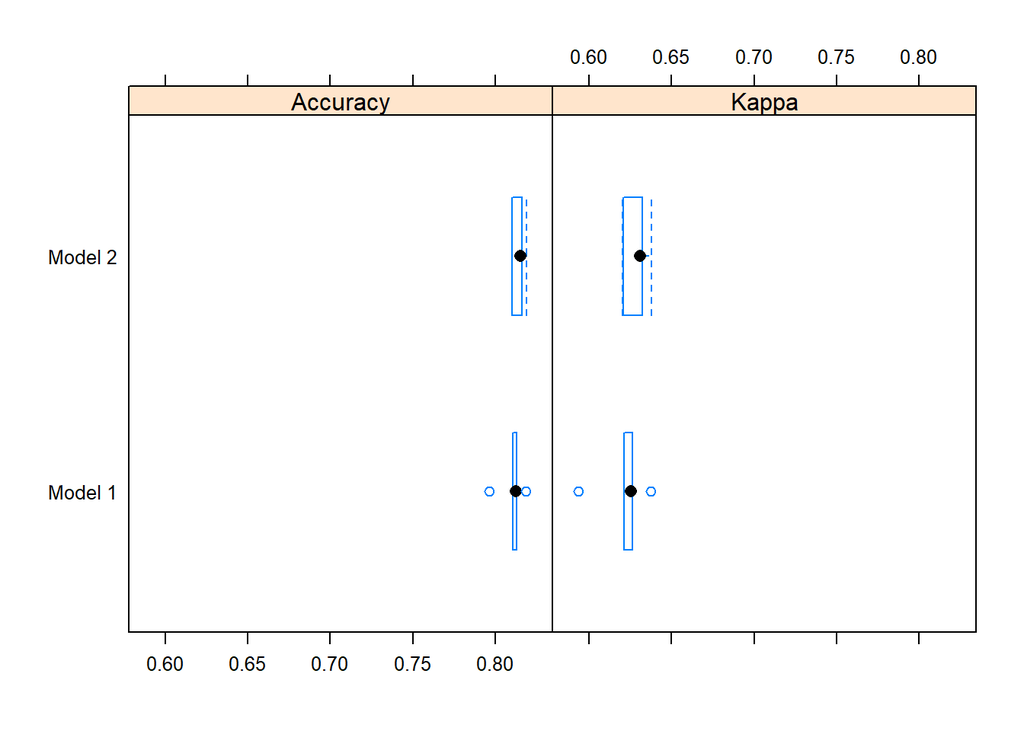

```r
results <- resamples(list('Model 1' = model1,'Model 2' = model2))
bwplot(results)
```

5. What is your final selection for the model? Test the accuracy of your final model on the test data.

Final selection is model 1.

```r
predictionFinal <- predict(model1, testdf)
confMatrixFinal <- confusionMatrix(data = predictionFinal, reference = testdf$target, positive = "low")
confMatrixFinal$overall[1]
```

```
##  Accuracy
## 0.8127363
```

6. Create another `target` variable (binary), decide the input variables and redo 1 to 5.

```r
df3_2 <- df3
df3_2$target <- case_when(df3$provider == '7205' ~ 'RI Hospital', TRUE ~ 'Other')
df3_2 <- df3_2 %>% select(-provider, -campus)
```

```r
df3_2 <- df3_2 %>%
  filter(raceethn!='',admtype!='') %>%
  mutate(target=as.factor(target),
    raceethn=as.factor(raceethn),
    admtype=as.factor(admtype))

set.seed(2020)
parts2 <- createDataPartition(df3_2$target, p = .1, list = FALSE)

traindf2 <- df3_2[ parts2,]
testdf2 <- df3_2[-parts2,]
```

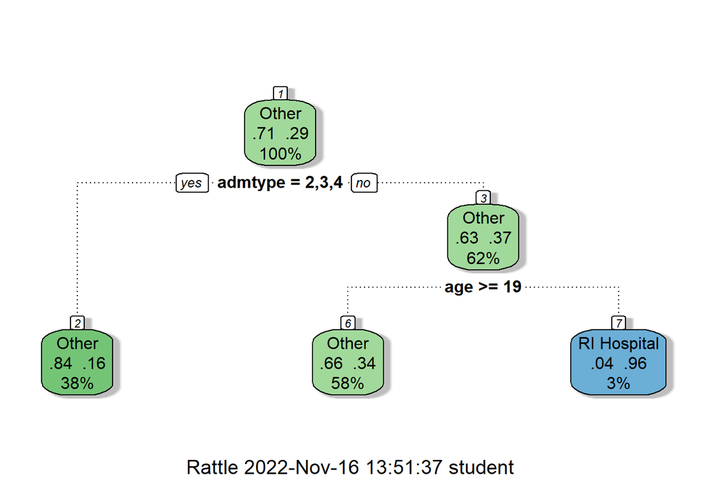

```r
library(rpart)
treedf2 <- rpart(target ~ ., data = traindf2, control = rpart.control(maxdepth = 3))
library(rattle)
fancyRpartPlot(treedf2)
```

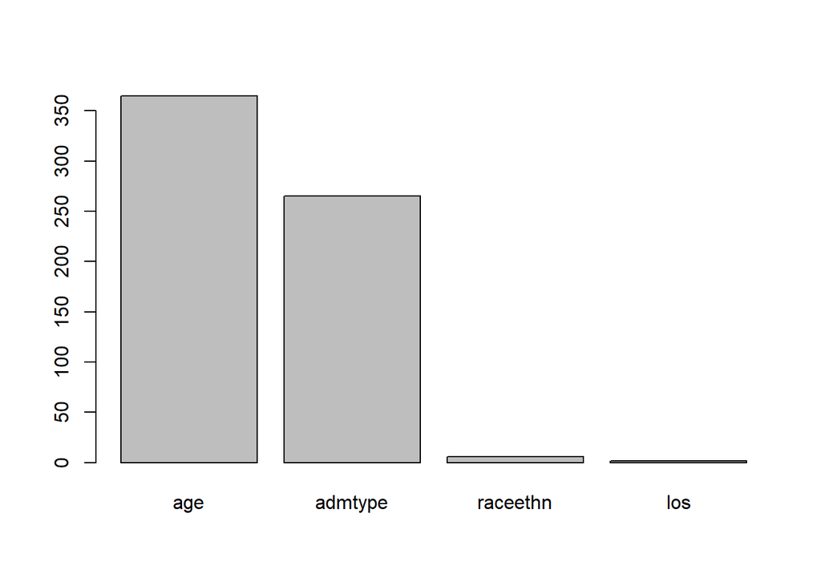

```r
barplot(treedf2$variable.importance)
```

```r
model3 <- train(target ~ ., data= traindf2 ,method = "rpart2",trControl = trControl, maxdepth = 5)

prediction3 <- predict(model3, testdf2)
confMatrix3 <- confusionMatrix(data = prediction3, reference = testdf2$target)
confMatrix3$overall[1]
```

```
##  Accuracy
## 0.7439925
```

```r
trControl = trainControl(method = "cv",number = 5)
tuneGrid = expand.grid(mtry = 2:4,splitrule = c('gini', 'extratrees'),min.node.size = c(1:10))
model4 <- train(target ~ ., data=traindf2,method = "treebag",trControl = trControl, maxdepth = 5)
prediction4 <- predict(model4, testdf2)
confMatrix4 <- confusionMatrix(data = prediction4, reference = testdf2$target)
confMatrix4$overall[1]
```

```
## Accuracy
## 0.705665
```

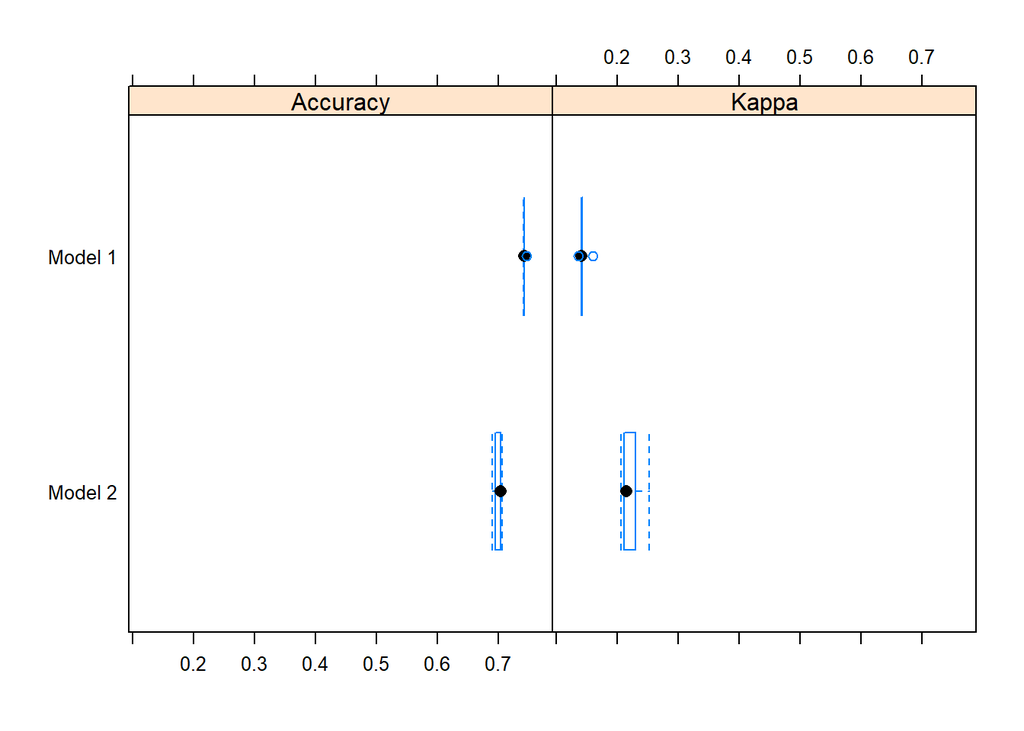

```r
results <- resamples(list('Model 1' = model3,'Model 2' = model4))
bwplot(results)
```

```r
predictionFinal <- predict(model4, testdf2)
confMatrixFinal <- confusionMatrix(data = predictionFinal, reference = testdf2$target, positive = "RI Hospital")
confMatrixFinal$overall[1]
```

```
## Accuracy
## 0.705665
```

7. Write a paragraph to summarize the section and give your comments on the results.

In this section, the models and decision trees turned out to have a decent level of accuracy. It is important to use multiple types of models in this case because there are some things that are covered by some models but not others, so creating multiple models allows us to get the most optimal one. In terms of the actual results, the accuracies for the first set of models turned out to be above 0.8, which was higher than those for the the binary models. For the binary models, it was necessary to remove some variables from the data set in order to prevent overfitting and confounding variables. After this was done, similar analyses were performed, and accuracies below 0.8 were produced. I was still able to select one model over the other, but this was not before running the training multiple times to get an accuarate model.